# Algoritmos de clasificación : SVM, Árboles de decisión simples y múltiples (random forest)

UOC - Master BI - Business Analytics (Nombre Estudiante)

Mayo de 2018

# 1 Base teórica

Esta práctica se basa en un ejemplo de **algoritmos de clasificación**. Durante la práctica se ilustran conceptos generales de metodologías de clasificación de algoritmos así como algunas técnicas habituales como son **SVM** y **Árboles de decisión**.

Cuando se trabajan con algoritmos de clasificación, es importante preparar de forma adecuada los conjuntos de entrenamiento (train set) y validación (validation set o test set). Los modelos se entrenan estrictamente con el conjunto de entrenamiento y, a continuación, se valida el modelo resultante sobre el conjunto de validación. Lo habitual es que el algoritmo funcione mejor con los datos de entrenamiento que con los datos de validación (que nunca ha visto antes). A este fenómeno se le llama sobreentrenamiento (**overfitting**) y es uno de los puntos clave a tener en cuenta cuando se implementa un sistema de clasificación, puesto que refleja la capacidad del modelo de generar resultados correctos frente a datos a los que no ha estado expuesto previamente.

**SVM (Support Vector Machines o máquinas de soporte vectorial)** tiene como objetivo encontrar el hiperplano óptimo que maximiza el margen entre clases (variable objetivo) del juego de datos de entrenamiento. Definiremos el margen como la zona de separación entre los distintos grupos a clasificar. Esta zona de separación quedará delimitada a través de hiperplanos. Las SVM buscan maximizar el margen entre los puntos pertenecientes a los distintos grupos a clasificar. Maximizar el margen implica que el hiperplano de decisión o separación esté diseñado de tal forma que el máximo número de futuros puntos queden bien clasificados

Los **Árboles de decisión** son algoritmos que construyen modelos de decisión que forman estructuras similares a los diagramas de flujo, donde los nodos internos suelen ser puntos de decisión sobre un atributo del juego de datos. Son muy dependientes del concepto de ganancia de la información ya que es el criterio que utilizan para construir las ramificaciones del árbol. A grandes rasgos existen dos tipos de árboles de decisión: * *Árboles de decisión simples*: el resultado se construye mediante un proceso de clasificación. * *Árboles de decisión múltiples (random forest)*: el resultado se construye mediante el desarrollo iterativo de *n* procesos de clasificación.

Aparte de los modelos propuestos en esta práctica, existe una gran variedad de alternativas de distinta complejidad, como los **modelos lineales generalizados**, los **métodos basados en kernel** o **redes neuronales**.

**Recursos en la web:**

- [Wikipedia: K-NN (k-vecinos más cercanos)](https://es.wikipedia.org/wiki/K-vecinos_m%C3%A1s_cercanos)
- [Wikipedia: Árbol de decisión simple](https://es.wikipedia.org/wiki/%C3%81rbol_de_decisi%C3%B3n)
- [Wikipedia: Árbol de decisión múltiple (Random forest)](https://es.wikipedia.org/wiki/Random_forest))
- [A Detailed Introduction to K-Nearest Neighbor (K-NN) Algorithm](https://saravananthirumuruganathan.wordpress.com/2010/05/17/a-detailed-introduction-to-k-nearest-neighbor-knn-algorithm/)
- [A Brief Tour of the Trees and Forests](http://www.r-bloggers.com/a-brief-tour-of-the-trees-and-forests/)
- [Linear classifiers] https://en.wikipedia.org/wiki/Linear_classifier
- [Generalized linear models] https://es.wikipedia.org/wiki/Modelo_lineal_generalizado
- [Kernel methods & SVM] https://en.wikipedia.org/wiki/Kernel_method
- [Neural networks] https://en.wikipedia.org/wiki/Artificial_neural_network

# 2 Caso de estudio: — Clasificación red de ventas Bodegas Mureda —

Formamos parte de la Dirección Comercial de la Bodega de vinos **Mureda** y queremos analizar la actividad de nuestra red de ventas, formada por tres categorías de comerciales (A, B y C). Para ello, estamos interesados en conocer: * si existen diferencias en la actividad generada por cada uno de los comerciales * en caso afirmativo: * identificar cuáles son las variables que más contribuyen a dichas diferencias * predecir a qué categoría de comercial pertenece un nuevo empleado en función de su actividad.

Para ello, nuestro equipo de análisis dispone de un fichero con información de 150 clientes que recoge estadísticas de actividad de los tres grupos de Comerciales, a razón de 50 registros por grupo de comercial. El fichero contiene información de las siguientes variables:

- *Importe*: Volumen de Facturación en el Cliente (vinculado a una categoría de Comercial)
- *Margen*: Margen por Cliente (vinculado a una categoría de Comercial)
- *Km*: Kilómetros recorridos para visitar al Cliente.
- *Visitas*: Visitas realizadas al Cliente.
- *Comercial*: Categoría de comercial asignada al cliente (Toma valores A, B ó C)

Una vez definidos los objetivos de nuestra investigación, nuestro departamento de análisis nos propone desarrollar un proceso de clasificación que aplique distintos modelos y que estudiemos qué algoritmos nos permiten extraer mejores resultados sobre nuestro conjunto de datos.

# 3 Apartados de la práctica

El código R que utilizaremos en la práctica se divide en apartados según las tareas que iremos realizando:

**Apartados práctica:**

- Carga de paquetes necesarios y fichero
- Análisis univariable y bivariable de los datos
  - Descriptivos de las variables del fichero
  - Estudio de la relación entre variables
  - Comparación de las variables por tipo de Comercial
- Preparación de los conjuntos de entrenamiento y validación
- Clasificación de los clientes con *SVM*
  - Construcción del Modelo de clasificación con *SVM*
  - Validación del Modelo de clasificación con *SVM*
- Clasificación de los clientes con árboles de decisión simples
  - Construcción del Modelo de clasificación con el paquete *rpart*
  - Validación del Modelo de clasificación con el paquete *rpart*
- Clasificación de los clientes con árboles de decisión múltiples (*random forest*)
  - Construcción del Modelo de clasificación con el paquete *randomForest*
  - Validación del Modelo de clasificación con el paquete *randomForest*

# 4 Carga de paquetes y del fichero de datos

Empezaremos por cargar los packages R que necesitaremos tener en memoria.

Cargamos también los datos ubicados en el fichero PEC3.csv

```r
# Cargamos los paquetes necesarios para desarrollar la PEC

#   Para representar gráficamente la relación entre variables
library("ggplot2")
#   Para clasificar con SVM
library('e1071')
#   Para clasificar con K-NN
library("class")
#   Para clasificar con rpart
library("rpart")
library("rpart.plot")
library("useful")
#   Para clasificar con randomForest
library("randomForest")
library("BBmisc")
# Cargamos el fichero de datos que utilizamos para desarrollar la PEC
nombreruta_PEC <- paste(getwd(),"/PEC3.csv", sep = "")
Data_PEC <- read.csv(nombreruta_PEC, encoding="UTF-8",
                      header=TRUE, sep=",", na.strings="NA", dec=".", strip.white=TRUE)
```

# 5 Análisis univariable y bivariable del fichero

La primera fase del análisis consiste siempre en un análisis descriptivo de las variables incluidas en el fichero y de la relación existente entre ellas. Para ello, aplicamos la siguiente secuencia de cálculos y representaciones gráficas.

1. Estadísticos descriptivos de las variables
2. Representación gráfica de cada una de las variables
3. Estudio de la relación entre las variables cuantitativas
4. Estudio de la existencia de diferencias por comercial

```r
# 1.Calculamos los descriptivos univariables de las variables del fichero
summary(Data_PEC) #Estadísticos descriptivos básicos de las variables
```

```
##     Ingresos        Margen            Km           Visitas      Comercial
##  Min.   :4300   Min.   :200.0   Min.   :10.00   Min.   : 1.00   A:50
##  1st Qu.:5100   1st Qu.:280.0   1st Qu.:16.00   1st Qu.: 3.00   B:50
##  Median :5800   Median :300.0   Median :43.50   Median :13.00   C:50
##  Mean   :5843   Mean   :305.4   Mean   :37.59   Mean   :11.99
##  3rd Qu.:6400   3rd Qu.:330.0   3rd Qu.:51.00   3rd Qu.:18.00
##  Max.   :7900   Max.   :440.0   Max.   :69.00   Max.   :25.00
```

Algunos de los estadísticos descriptivos de posición que caracterizan a las 5 variables son:

- *Importe*: Promedio de 5.843, Máximo 7.900, Mínimo 4.300
- *Margen*: Promedio de 305,4, Máximo 440, Mínimo 200
- *Km*: Promedio de 37,59, Máximo 69, Mínimo 10
- *Visitas*: Promedio de 11,99, Máximo 25, Mínimo 1
- *Comercial*: 50 observaciones por comercial

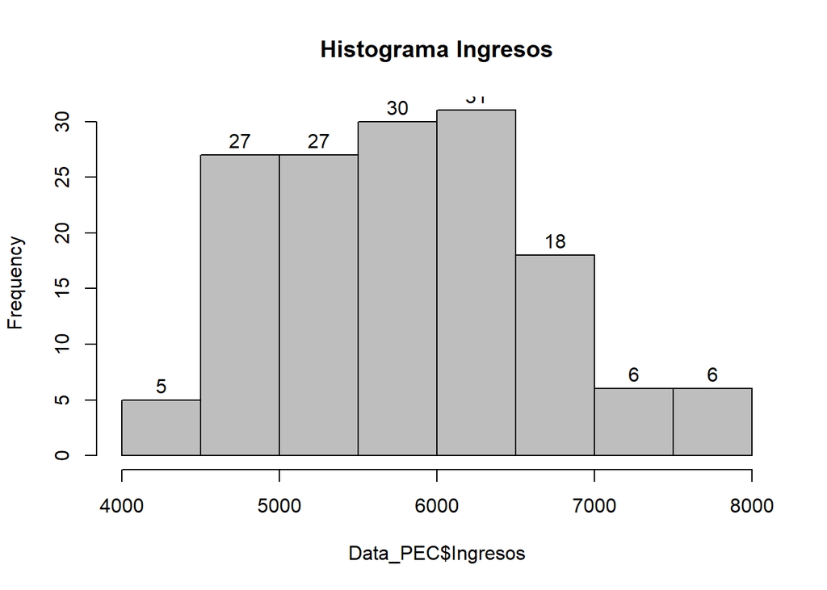

```r
# 2.Representamos gráficamente las variables del fichero mediante histogramas

#Histograma Ingresos
f1 <- hist(Data_PEC$Ingresos, main="Histograma Ingresos", col = "gray", labels = TRUE)
```

```r
f1
```

```
## $breaks
## [1] 4000 4500 5000 5500 6000 6500 7000 7500 8000
##
## $counts
## [1]  5 27 27 30 31 18  6  6
##
## $density
## [1] 6.666667e-05 3.600000e-04 3.600000e-04 4.000000e-04 4.133333e-04
## [6] 2.400000e-04 8.000000e-05 8.000000e-05
##
## $mids
## [1] 4250 4750 5250 5750 6250 6750 7250 7750
##
## $xname
## [1] "Data_PEC$Ingresos"
##
## $equidist
## [1] TRUE
##
## attr(,"class")
## [1] "histogram"
```

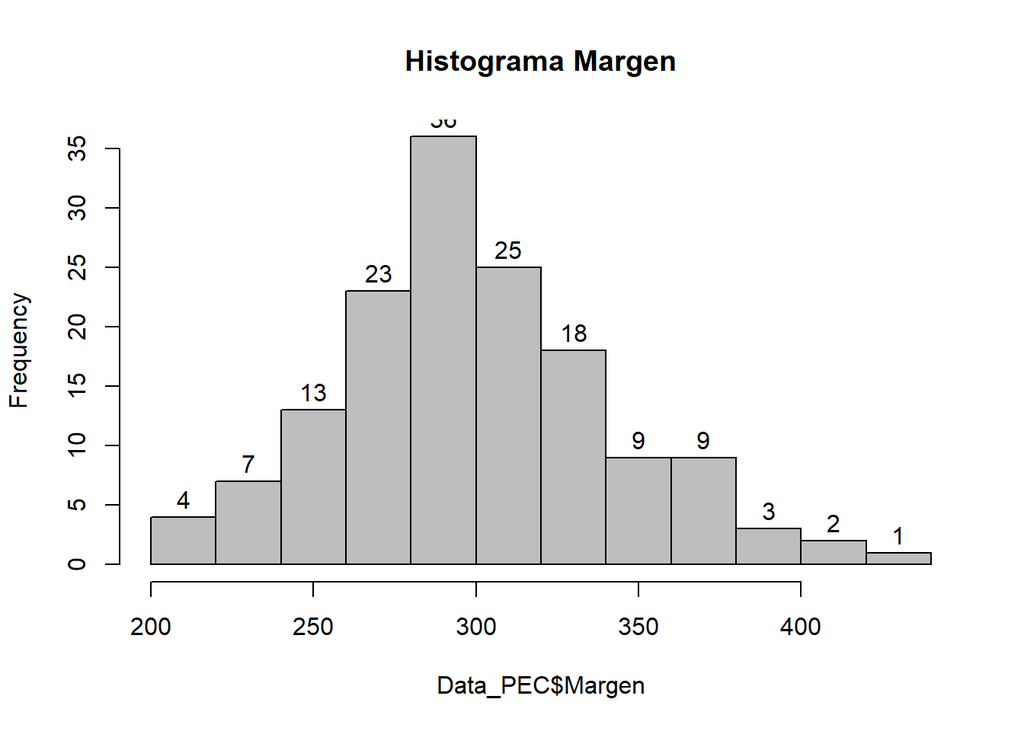

```r
#Histograma Margen
f2 <- hist(Data_PEC$Margen, main="Histograma Margen", col = "gray", labels = TRUE)
```

```r
f2
```

```
## $breaks
##  [1] 200 220 240 260 280 300 320 340 360 380 400 420 440
##
## $counts
##  [1]  4  7 13 23 36 25 18  9  9  3  2  1
##
## $density
##  [1] 0.0013333333 0.0023333333 0.0043333333 0.0076666667 0.0120000000
##  [6] 0.0083333333 0.0060000000 0.0030000000 0.0030000000 0.0010000000
## [11] 0.0006666667 0.0003333333
##
## $mids
##  [1] 210 230 250 270 290 310 330 350 370 390 410 430
##
## $xname
## [1] "Data_PEC$Margen"
##
## $equidist
## [1] TRUE
##
## attr(,"class")
## [1] "histogram"
```

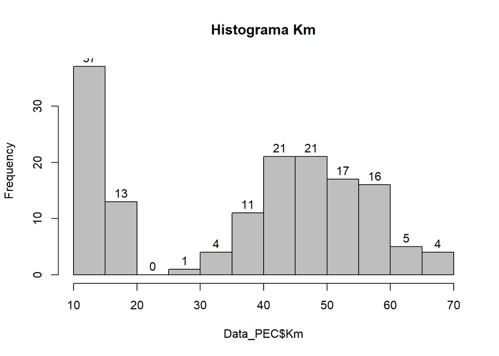

```r
#Histograma Km
f3 <- hist(Data_PEC$Km, main="Histograma Km", col = "gray", labels = TRUE)
```

```r
f3
```

```
## $breaks
##  [1] 10 15 20 25 30 35 40 45 50 55 60 65 70
##
## $counts
##  [1] 37 13  0  1  4 11 21 21 17 16  5  4
##
## $density
##  [1] 0.049333333 0.017333333 0.000000000 0.001333333 0.005333333
##  [6] 0.014666667 0.028000000 0.028000000 0.022666667 0.021333333
## [11] 0.006666667 0.005333333
##
## $mids
##  [1] 12.5 17.5 22.5 27.5 32.5 37.5 42.5 47.5 52.5 57.5 62.5 67.5
##
## $xname
## [1] "Data_PEC$Km"
##
## $equidist
## [1] TRUE
##
## attr(,"class")
## [1] "histogram"
```

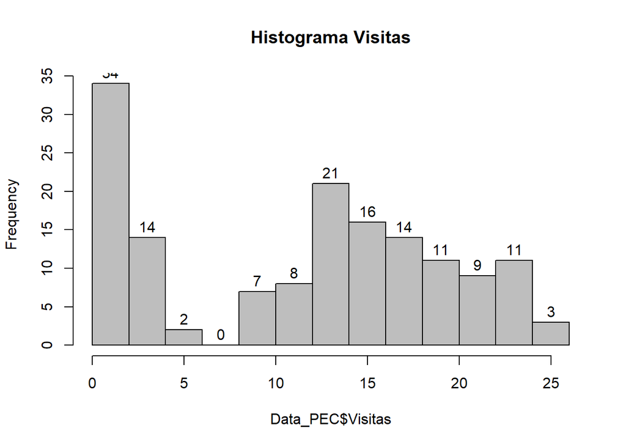

```r
#Histograma Visitas
f4 <- hist(Data_PEC$Visitas, main="Histograma Visitas", col = "gray", labels = TRUE)
```

```r
f4
```

```
## $breaks
##  [1]  0  2  4  6  8 10 12 14 16 18 20 22 24 26
##
## $counts
##  [1] 34 14  2  0  7  8 21 16 14 11  9 11  3
##
## $density
##  [1] 0.113333333 0.046666667 0.006666667 0.000000000 0.023333333
##  [6] 0.026666667 0.070000000 0.053333333 0.046666667 0.036666667
## [11] 0.030000000 0.036666667 0.010000000
##
## $mids
##  [1]  1  3  5  7  9 11 13 15 17 19 21 23 25
##
## $xname
## [1] "Data_PEC$Visitas"
##
## $equidist
## [1] TRUE
##
## attr(,"class")
## [1] "histogram"
```

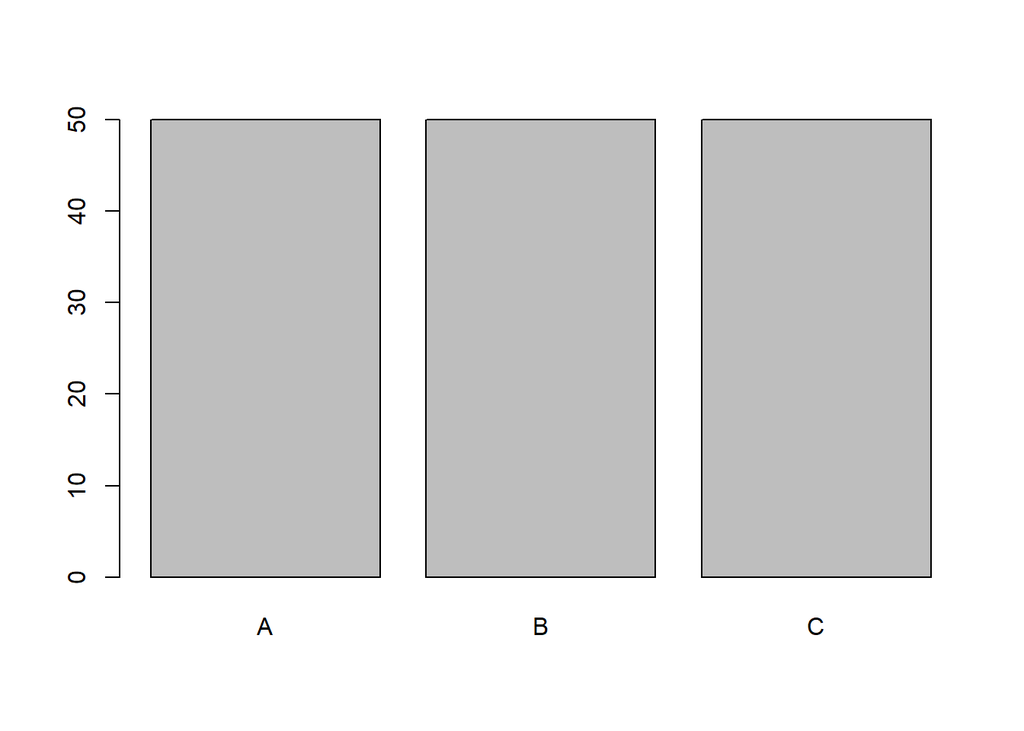

```r
#Histograma Comercial
f5 <- plot(Data_PEC$Comercial)
```

```r
f5
```

```
##      [,1]
## [1,]  0.7
## [2,]  1.9
## [3,]  3.1
```

Las variables cuantitativas presentan dos distribuciones diferenciadas:

- *Importe* y *Margen* presentan una distribución similar a una campana de *Gauss*, algo más concentrada en el caso de *Margen*
- *Km* y *Visitas* presentan una distribución muy similar. Con una alta concentración para valores bajos que desciende rápidamente para volver a crecer siguiendo una campana de *Gauss* a partir del tercer valor de la serie.

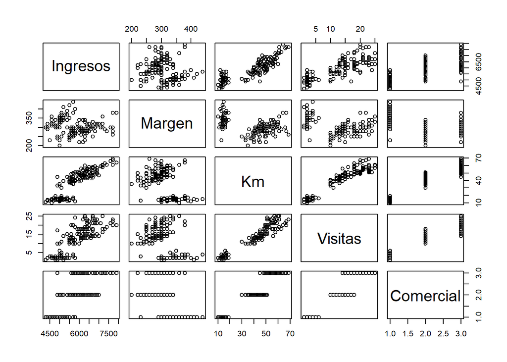

```r
# 3.Estudiamos la relación existente entre las variables del fichero

# Estudiamos la relación entre variables mediante gráficos de dispersión
f6<- plot(Data_PEC)
```

```r
f6
```

```r
# Estudiamos la relación entre variables cuantitativas mediante correlaciones
cor(Data_PEC[,c("Ingresos","Margen","Km","Visitas")], use="complete")
```

```
##            Ingresos     Margen         Km    Visitas
## Ingresos  1.0000000 -0.1093692  0.8717542  0.8179536
## Margen   -0.1093692  1.0000000 -0.4205161 -0.3565441
## Km        0.8717542 -0.4205161  1.0000000  0.9627571
## Visitas   0.8179536 -0.3565441  0.9627571  1.0000000
```

- Coeficiente de Correlación *Visitas*-*Km* -> (0,96)
- Coeficiente de Correlación *Ingresos*-*Km* -> (0,87)
- Coeficiente de Correlación *Ingresos*-*Visitas* -> (0,82)
- Coeficiente de Correlación *Margen*-*Km* -> (-0,42)

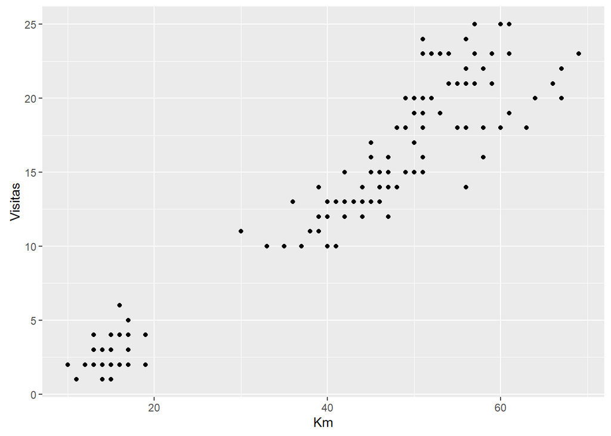

```r
# Estudiamos la relación entre variables Km y Visitas
f7<-ggplot(Data_PEC, aes(x=Km, y=Visitas)) + geom_point()
f7
```

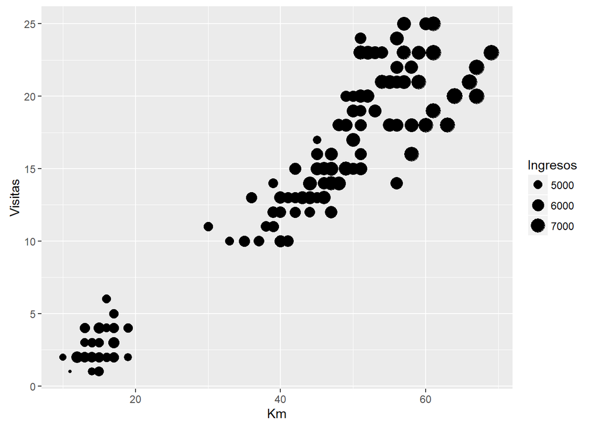

```r
# Estudiamos la relación entre variables Km y Visitas con tamañoo ingresos
f8<-ggplot(Data_PEC, aes(x=Km, y=Visitas)) + geom_point(aes(size=Ingresos))
f8
```

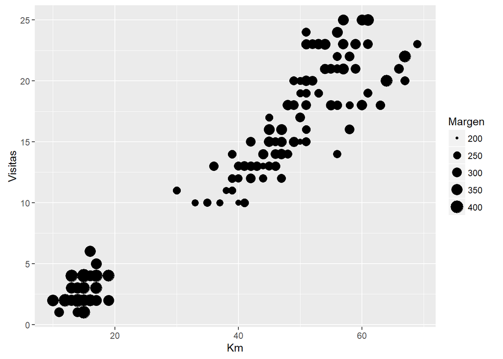

```r
# Relación entre variables Km y Visitas con tamaño margen
f9<-ggplot(Data_PEC, aes(x=Km, y=Visitas)) + geom_point(aes(size=Margen))
f9
```

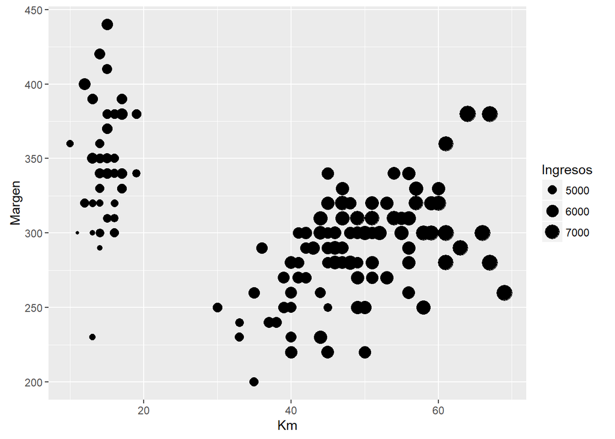

```r
# Relación entre variables Km y Visitas con tamaño margen
fA<-ggplot(Data_PEC, aes(x=Km, y=Margen)) + geom_point(aes(size=Ingresos))
fA
```

```r
# 3.Estudiamos la existencia de diferencias por Comercial

# promedio variables por comercial
tapply(Data_PEC$Ingresos,Data_PEC$Comercial,mean)
```

```
##    A    B    C
## 5006 5936 6588
```

```r
tapply(Data_PEC$Margen,Data_PEC$Comercial,mean)
```

```
##     A     B     C
## 341.8 277.0 297.4
```

```r
tapply(Data_PEC$Km,Data_PEC$Comercial,mean)
```

```
##     A     B     C
## 14.64 42.60 55.52
```

```r
tapply(Data_PEC$Visitas,Data_PEC$Comercial,mean)
```

```
##     A     B     C
##  2.44 13.26 20.26
```

Vemos que existen diferencias remarcables en el promedio de cada una de las variables para cada Comercial:

Graficamos a continuación las variables cuantitativas diferenciando por Comercial.

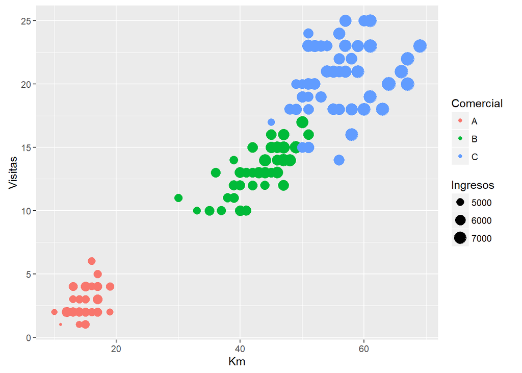

```r
# Relación entre variables Km y Visitas con tamaño ingresos y Color según Comercial
f10<-ggplot(Data_PEC, aes(x=Km, y=Visitas, color=Comercial)) + geom_point(aes(size=Ingresos))
f10
```

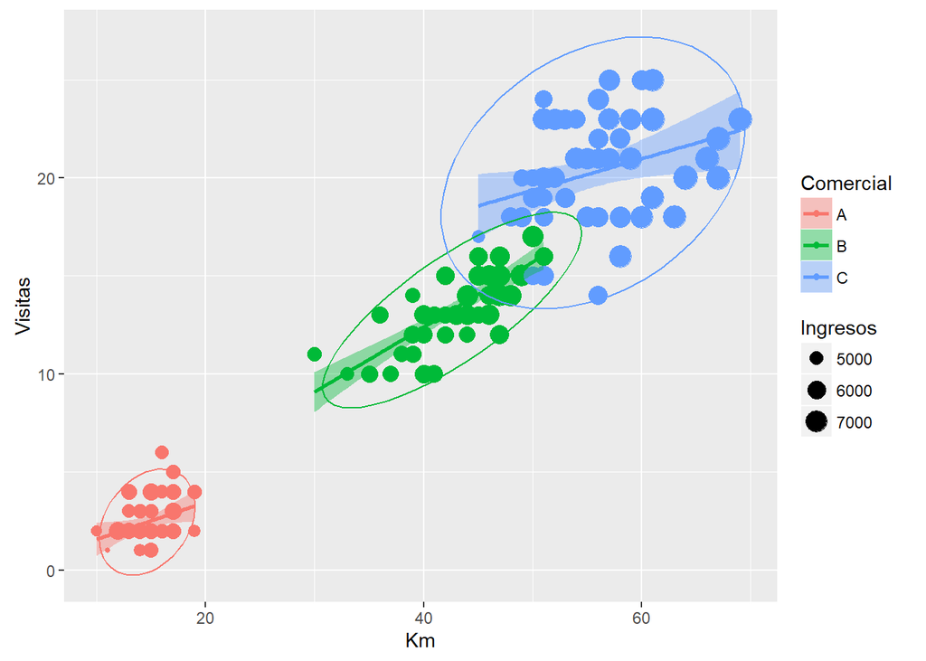

```r
# Relación entre variables Km y Visitas con tamaño ingresos y Color según Comercial, línea tendencia y elipse
f11<-ggplot(Data_PEC, aes(x=Km, y=Visitas, color=Comercial)) + geom_point(aes(size=Ingresos)) + geom_smooth(method=lm, aes(fill=Comercial))+ stat_ellipse(type = "norm")
f11
```

Identificamos un comportamiento diferenciado donde *Km* y *Visitas* ya que son las variables que presentan una mayor capacidad de diferenciación.

# 6 Preparación de los conjuntos de entrenamiento y validación

Construimos un **juego de datos de entrenamiento** con el 70% de registros para construir los modelos y un **juego de datos de pruebas o validación** con el 30% de registros restantes para validar los modelos. Esta separación de ambos conjuntos es aleatoria.

Separamos los datos en entrenamiento y validación antes de proceder con el resto de ejercicios para asegurar que los datos de entrenamiento y validación son iguales en todos los casos y los resultados son comparables. Si lo hiciésemos de otro modo, las diferencias en la calidad de los modelos podrían ser debidas a una separación distinta entre los conjuntos de entrenamiento y validación.

```r
# Dividimos el fichero en 70% entreno y 30% validación  #
set.seed(1234)  # Seed inicializa el generador de números aleatorios que usaremos para separar los datos en train y test. Usando un seed fijo, nos aseguramos de que todos generamos los mismos conjuntos y los resultados son reproducibles
ind <- sample(2, nrow(Data_PEC), replace=TRUE, prob=c(0.7, 0.3))
trainData <- Data_PEC[ind==1,]
testData <- Data_PEC[ind==2,]
```

# 7 Proceso de clasificación mediante SVM.

**Aplicamos el modelo SVM**, pasándole como parámetros la matriz de entrenamiento compuesta por las 4 variables cuantitativas : *Importe*, *Margen*, *Km* y *Visitas*. No le pasamos el campo *Comercial* porque precisamente es el campo que el algoritmo debe predecir.

```r
# Entrenamos el modelo SVM
model_svm = svm(trainData[,1:4], trainData$Comercial)
# Usamos el modelo que hemos entrenado para generar una predicción para cada muestra del conjunto de validación
preds_svm = predict(model_svm, testData[,1:4])
# Calculamos el % de aciertos de nuestro modelo
sum(preds_svm == testData$Comercial)/ length(testData$Comercial)*100
```

```
## [1] 94.73684
```

Evaluamos el % de acierto del modelo SVM que hemos entrenado.

SVM genera un 94.73% de acierto sobre los datos propuestos.

# 8 Proceso de clasificación mediante Árboles de decisión simples

Para construir un árbol de decisión es necesario definir una función que relaciona una variable categórica dependiente (factor) con *n* variables independientes que pueden ser categóricas o numéricas. En nuestro caso trabajaremos con:

- 1 variable factor dependiente -> *Comercial*
- 4 variables independientes -> *Ingresos*, *Margen*, *Km* y *Visitas*

El algoritmo de clasificación busca cuál es la variable que permite obtener una submuestra más diferenciada para la variable dependiente (*Comercial* en nuestro caso) e identifica también qué intervalos (si la variable es cuantitativa) ó agrupación de categorías de la/s variable/s independiente/s permitiría/n maximizar dicha división.

Una vez identificada la variable independiente que permite obtener la clasificación con una mayor capacidad de diferenciación, el proceso se repite reiterativamente en cada uno de los nodos obtenidos hasta que el algoritmo no encuentra diferencias significativas que le permitan seguir profundizando en los nodos.

Una vez obtenido una primera versión del árbol, existen algoritmos que permiten hacer un podado del árbol (*prunning*), eliminando aquellas ramas que no acaban de justificar su presencia de acuerdo con algunos parámetros preestablecidos.

En todos los casos seguiremos la siguiente secuencia de pasos para obtener los Árboles de clasificación:

1. Definir la función que relaciona la variable dependiente con las variables independientes
2. Estimar el árbol de decisión
3. Representar gráficamente una primera versión del árbol
- Estudiar la aplicación práctica del resultado obtenido
- Podar el árbol (si el algoritmo admite podado)
4. Estudiar la capacidad predictiva del árbol

Estudiamos a continuación la capacidad predictiva del Árbol de decisión simple obtenido mediante el paquete *rpart*

```r
#Declaramos función del árbol
ArbolRpart = Comercial ~ Ingresos + Margen + Km + Visitas
#Aplicamos algoritmo
model_tree = rpart(ArbolRpart, method="class", data=trainData)
# Validamos la capacidad de predicción del árbol con el fichero de validación
preds_tree <- predict(model_tree, newdata = testData, type = "class")
# Visualizamos una matriz de confusión
table(preds_tree, testData$Comercial)
```

```
##
## preds_tree  A  B  C
##          A 10  0  0
##          B  0 12  2
##          C  0  0 14
```

```r
# Calculamos el % de aciertos
sum(preds_tree == testData$Comercial)/ length(testData$Comercial)*100
```

```
## [1] 94.73684
```

El árbol de decisión obtenido mediante el paquete *rpart* clasifica correctamente un 94,73% de los registros. Un resultado bastante alto y aceptable.

Una vez construida una primera versión del árbol, estudiamos la viabilidad de un podado de árbol.

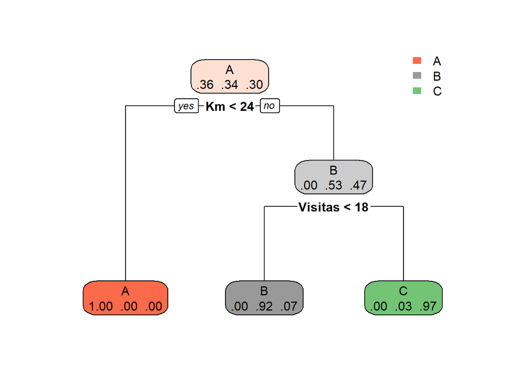

```r
# Podado del árbol
pruned_tree_model <- prune(model_tree, cp= model_tree$cptable[which.min(model_tree$cptable[,"xerror"]),"CP"])
pruned_tree_model <- prune(pruned_tree_model, cp= 0.02)
# Representación del árbol podado
f14<-rpart.plot(pruned_tree_model,extra=4) #visualizamos el árbol
```

```r
f14
```

[output not shown]

[output cut: 23 more lines]

[output not shown]

Dado que el árbol original es muy simple. El podado no devuelve ninguna versión nueva reducida.

# 9 Proceso de clasificación mediante árboles de decisión múltiples (paquete randomForest)

El algoritmo *randomForest* es un método de estimación combinado, donde el resultado de la estimación se construye a partir de los resultados obtenidos mediante el cálculo de *n* árboles donde los predictores son incluidos al azar.

Es un método complejo con ventajas e inconvenientes respecto a los árboles de clasificación simples:

*Ventajas*

- Es uno de los algoritmos de aprendizaje más precisos
- Se ejecuta eficientemente en grandes bases de datos
- Permite trabajar con cientos de variables independientes sin excluir ninguna
- Determina la importancia en la clasificación de cada variable
- Recupera eficazmente los valores perdidos de un dataset (*missings*)
- Permite evaluar la ganancia en clasificación obtenida a medida que incrementamos el número de árboles generados en el modelo.

*Inconvenientes*

- A diferencia de los árboles de decisión, la clasificación hecha por *random forests* es difícil de interpretar
- Favorece las variables categóricas que tienen un mayor número de niveles por encima de aquéllas que tienen un número de categoría más reducido. Comprometiendo la fiabilidad del modelo para este tipo de datos.
- Favorece los grupos más pequeños cuando las variables están correlacionadas
- randomForest sobreajusta en ciertos grupos de datos con tareas de clasificación/regresión ruidosas

```r
set.seed(12)
#Declaramos función del árbol
ArbolRF <- Comercial ~ Ingresos + Margen + Km + Visitas
#Aplicamos algoritmo
model_random_forest <- randomForest(ArbolRF, data=trainData, ntree=500,proximity=T,nodesize=5) #indicamos el número de árboles mediante ntree=500
#Obtenemos la importancia de cada variable en el proceso de clasificación
importance(model_random_forest)      #Importancia de las variables en formato text
```

```
##          MeanDecreaseGini
## Ingresos        6.3238674
## Margen          0.9922122
## Km             30.3160679
## Visitas        33.6052270
```

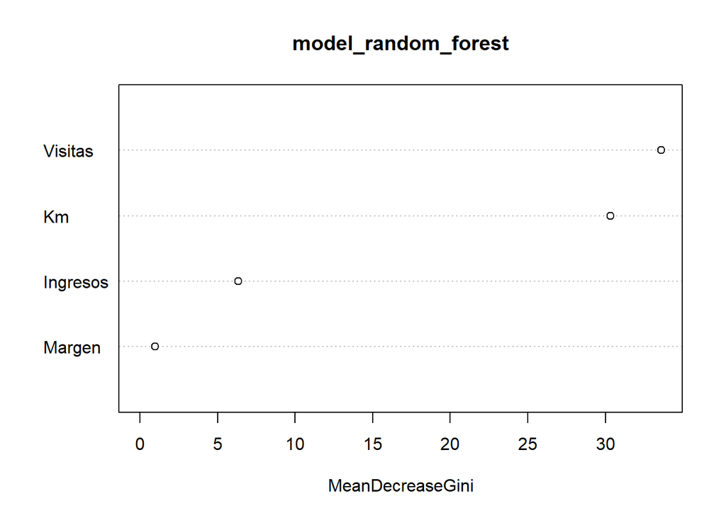

```r
f15<-varImpPlot(model_random_forest) #Importancia de las variables en formato gráfico
```

```r
f15
```

```
##          MeanDecreaseGini
## Ingresos        6.3238674
## Margen          0.9922122
## Km             30.3160679
## Visitas        33.6052270
```

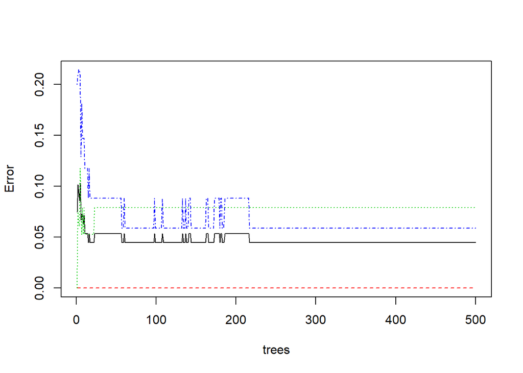

```r
#evolución del error según el número de árboles
f16<-plot(model_random_forest, main = "")
```

```r
head(f16)
```

```
##             OOB A          B         C
## [1,] 0.07500000 0 0.00000000 0.2000000
## [2,] 0.10144928 0 0.07692308 0.2083333
## [3,] 0.09302326 0 0.06451613 0.2142857
## [4,] 0.08602151 0 0.06060606 0.2142857
## [5,] 0.10309278 0 0.11764706 0.2068966
## [6,] 0.06666667 0 0.07894737 0.1290323
```

```r
# Validamos la capacidad de predicción del árbol con el fichero de validación
preds_random_forest <- predict(model_random_forest, newdata = testData)
table(preds_random_forest, testData$Comercial)
```

```
##
## preds_random_forest  A  B  C
##                   A 10  0  0
##                   B  0 12  1
##                   C  0  0 15
```

```r
# Calculamos el % de aciertos
sum(preds_random_forest == testData$Comercial)/ length(testData$Comercial)*100
```

```
## [1] 97.36842
```

El árbol de decisión obtenido mediante el paquete *randomForest* clasifica correctamente un 97,36% de los registros. Un resultado bastante alto y aceptable.

# 10 Ejercicios

## 10.1 Pregunta 1

Al inicio de la práctica hemos separado el conjunto de datos en entrenamiento y validación y hemos entrenado el modelo usando sólo el conjunto de entrenamiento. A continuación, hemos comprobado si el modelo había aprendido mediante el conjunto de validación. Explicad por qué es importante separar los datos en dos conjuntos sin solapamiento. ¿Qué sucedería si usamos todo el conjunto de datos para entrenar y no apartamos unas muestras para validar?

Ilustrad vuestra explicación empíricamente. Usad el modelo ‘model_svm’ que hemos entrenado durante la práctica y utilizadlo para generar predicciones sobre los datos de entrenamiento. A continuación haced lo mismo usando el conjunto de validación. Puede usar el siguiente código de muestra para generar las predicciones propuestas. Calcule el índice de aciertos en cada caso y justifique el resultado.

```r
# Vamos a utilizar el modelo entrenado previamente (model_svm)
## Generamos predicciones sobre los datos de train
predicions_on_train_svm = predict(model_svm, trainData[,1:4], type = 'class')
## Generamos predicciones sobre los datos de validación
predicions_on_test_svm  = predict(model_svm,  testData[,1:4], type = 'class')
```

## 10.2 Respuesta 1

Se generan dos conjuntos de datos para que la validacion sea independiente del entrenamiento, es decir, si usaramos el dataset entero para entrenar y luego tambien para validar, nuestra validacion estaria contaminada ya que nuestro modelo estaria entrenado especificamente para esos datos.

```r
# Predicciones, una con el propio dataset de entrenamiento y otra con el de test
predicions_on_train_svm = predict(model_svm, trainData[,1:4], type = 'class')
predicions_on_test_svm  = predict(model_svm,  testData[,1:4], type = 'class')

# % de acierto
sum(predicions_on_train_svm == trainData$Comercial)/ length(trainData$Comercial)*100
```

```
## [1] 97.32143
```

```r
sum(predicions_on_test_svm == testData$Comercial)/ length(testData$Comercial)*100
```

```
## [1] 94.73684
```

## 10.3 Pregunta 2

A la vista de los resultados que se muestran a continuación, es el algoritmo SVM un algoritmo determinístico? Razone la respuesta explicando detalladamente qué es y cuál es la utilidad del ‘seed’.

```r
set.seed(12)
preds  = predict(model_svm, testData[,1:4], type = 'class')
sum(preds == testData$Comercial)/ length(testData$Comercial)*100
```

```
## [1] 94.73684
```

```r
set.seed(1234)
preds  = predict(model_svm, testData[,1:4], type = 'class')
sum(preds == testData$Comercial)/ length(testData$Comercial)*100
```

```
## [1] 94.73684
```

```r
set.seed(12345)
preds  = predict(model_svm, testData[,1:4], type = 'class')
sum(preds == testData$Comercial)/ length(testData$Comercial)*100
```

```
## [1] 94.73684
```

## 10.4 Respuesta 2

Si, el algoritmo svm es un algoritmo determinista,ya que, conociendo las entradas puedes conocer las salidas. Es un clasificador que dice si un conjunto de datos son x o y. Estos estan separados por un hyperplano y es este el que determina a que categoria pertenecen. La seed lo que determina es la aleatoriedad con la que va a realizar las operaciones, la seed es una manera de poder reproducir los resultados de nuevo con la determinacion de que la manera de hacerlo es la misma.

## 10.5 Pregunta 3

Explique con sus palabras en qué consiste el algoritmo SVM y qué importancia tiene el Kernel utilizado. Teniendo ésto en cuenta, ¿normalizar los datos mejora la clasificación? Ilustre su respuesta con un ejemplo.

Entrene y testee un svm normalizando y sin normalizar los datos. Tenga en cuenta que ‘svm’ acepta un parámetro que indica si los datos deben ser o no normalizados tal como muestra el siguiente ejemplo:

```r
example_trained_model = svm(trainData[,1:4], trainData$Comercial, scale = TRUE)
```

## 10.6 Respuesta 3

El algoritmo SVM es de clasoificacion como se ha dicho arriba. La importancia del kernel a utilizar es muy alta ya que este determina como variara y como se transformara la linea (el hyperplano) que separa los datos. El algoritmo se entrena y este determina la distancia entre los puntos y sus variables despues se “dibuja” una linea separando entre ambos grupos. El kernel por defecto es RBF.

La normalizacion es muy importante, ya que, al estar calculando las distancias, el hecho de que una variable determine km y otra edad afectaria al algoritmo, teniendo en los kilometros una distancia mayor que en la edad, dando mas peso a los kilometros. El normalizar los datos equipara y estandariza todas las variables en un rango, haciendolas todas “iguales” ante los ojos del algoritmo.

```r
# Creamos dos modelos uno con datos normalizados y otro con datos sin normalizar
no_normal_model_svm = svm(trainData[,1:4], trainData$Comercial, scale = FALSE)
normal_model_svm = svm(trainData[,1:4], trainData$Comercial, scale = TRUE)

# Hacemos las predicciones
predic_no_normal_svm  = predict(no_normal_model_svm,  testData[,1:4], type = 'class')
predic_normal_svm = predict(normal_model_svm, testData[,1:4], type = 'class')

# Calculamos el % de aciertos de nuestros modelos
sum(predic_no_normal_svm == testData$Comercial)/ length(testData$Comercial)*100
```

```
## [1] 31.57895
```

```r
sum(predic_normal_svm == testData$Comercial)/ length(testData$Comercial)*100
```

```
## [1] 94.73684
```

## 10.7 Pregunta 4

Por defecto, el kernel usado en svm es RBF (Radial Basis Function). Comprobad cómo afecta el uso de un kernel lineal. ¿Qué diferencia veis entre los dos kernels cuando los datos no se estandarizan?

Entrene un modelo SVM sin estandarizar (scale = False) utilizando un kernel lineal y un kernel radial. Compare los resultados y justifique la respuesta

# 11 Respuesta 4

```r
# Los dos modelos
radial_svm = svm(trainData[,1:4], trainData$Comercial, scale = FALSE, kernel = "radial")
lineal_svm = svm(trainData[,1:4], trainData$Comercial, scale = FALSE, kernel = "linear")

# Predicciones
predic_radial_svm  = predict(radial_svm,  testData[,1:4], type = 'class')
predic_lineal_svm = predict(lineal_svm, testData[,1:4], type = 'class')

# % De acierto
sum(predic_radial_svm == testData$Comercial)/ length(testData$Comercial)*100
```

```
## [1] 31.57895
```

```r
sum(predic_lineal_svm == testData$Comercial)/ length(testData$Comercial)*100
```

```
## [1] 100
```

Para datos no normalizados el kernel radial no clasifica correctamente casi el 69% de los datos, siendo asi una gran falta de precision. En cambios el linear con datos no normalizados tiene un 100% de acierto. Lo cual suena muy bien, pero clasificar el 100% de manera correcta no es algo de lo que alegrarse ya que lña experiencia nos dice que es casi imposible que se clasifique el 100% de los datos de manera correcta.

## 11.1 Pregunta 5

Siguiendo con la pregunta anterior, qué importancia tiene normalizar los datos si el modelo utilizado es un modelo basado en Árboles (Random Forests, Decission Trees…) en lugar de un SVM?

Opcionalmente, ilustre su respuesta empíricamente repitiendo el ejercicio anterior entrenando y evaluando un RandomForest normalizando y sin normalizar los datos.

## 11.2 Respuesta 5

Em ramdom forest la distancia de una variable no afecta a las demas por lo tanto no es tan importante la normalizacion.

```r
set.seed(22)
# Creamos de nuevo un indice para tener los mismos datos normalizados y no normalizados
normal_data = normalize(Data_PEC)
ind <- sample(2, nrow(Data_PEC), replace=TRUE, prob=c(0.7, 0.3))
# Separamos lo datos entre train y test normalizados y no normalizados
trainData <- Data_PEC[ind==1,]
testData <- Data_PEC[ind==2,]
normal_trainData <- normal_data[ind==1,]
normal_testData <- normal_data[ind==2,]
#Funcion
ArbolRF <- Comercial ~ Ingresos + Margen + Km + Visitas
#Aplicamos
normal_random_forest <- randomForest(ArbolRF, data=normal_trainData, ntree=500,proximity=T,nodesize=5)
random_forest <- randomForest(ArbolRF, data=trainData, ntree=500,proximity=T,nodesize=5)
# Prediccion
predic_normal_random_forest <- predict(normal_random_forest, newdata = normal_testData)
predic_random_forest <- predict(random_forest, newdata = testData)
# Precision
sum(predic_normal_random_forest == normal_testData$Comercial)/ length(normal_testData$Comercial)*100
```

```
## [1] 95.34884
```

```r
sum(predic_random_forest == testData$Comercial)/ length(testData$Comercial)*100
```

```
## [1] 95.34884
```

Vemos que no hay diferencia entre los datos normalizados y no normalizados.

## 11.3 Pregunta 6

Es habitual combinar los resultados de distintos modelos para reforzar sus respectivas predicciones. Este procedimiento se denomina habitualmente “ensamblado”. Construya un modelo ensamblando los modelos vistos durante la práctica: SVM, el Árbol y el randomForest. ¿Mejora el ensemble las métricas obtenidas por los modelos ensamblados?

Para hacerlo, construya un modelo ensamblado, es decir, para cada registro, cada modelo realiza una predicción para la categoría. El modelo ensamblado debe asignar a cada registro la categoría más repetida de las tres. Calcule el acierto del modelo resultante. Tome la variable ‘models_to_ensemble’ como entrada.

```r
models_to_ensemble <- data.frame(preds_svm, preds_tree, preds_random_forest)
```

## 11.4 Respuesta 6

Por lo general al ser el ensemble una manera de mejorar y asegurar los resultado deberiamos ver mejores resultados, ya que unos se nutren de los otros.

```r
models_to_ensemble <- data.frame(preds_svm, preds_tree, preds_random_forest)
models_to_ensemble$pred_majority<-as.factor(ifelse(models_to_ensemble$preds_svm=='A' & models_to_ensemble$preds_tree=='A','A', ifelse(models_to_ensemble$preds_svm=='A' & models_to_ensemble$preds_random_forest=='A','A', ifelse(models_to_ensemble$preds_tree=='A' & models_to_ensemble$preds_random_forest=='A','A', ifelse(models_to_ensemble$preds_svm=='B' & models_to_ensemble$preds_tree=='B','B', ifelse(models_to_ensemble$preds_svm=='B' & models_to_ensemble$preds_random_forest=='B','B', ifelse(models_to_ensemble$preds_tree=='B' & models_to_ensemble$preds_random_forest=='B','B','C')))))))
#Evaluamos
sum(models_to_ensemble$preds_svm == testData$Comercial)/ length(testData$Comercial)*100
```

```
## [1] 67.44186
```

```r
sum(models_to_ensemble$preds_tree == testData$Comercial)/ length(testData$Comercial)*100
```

```
## [1] 67.44186
```

```r
sum(models_to_ensemble$preds_random_forest == testData$Comercial)/ length(testData$Comercial)*100
```

```
## [1] 69.76744
```

```r
sum(models_to_ensemble$pred_majority == testData$Comercial)/ length(testData$Comercial)*100
```

```
## [1] 67.44186
```

## 11.5 Pregunta 7

Explique como mínimo una forma alternativa de generar un ensemble (busque en internet distintas alternativas si le resulta necesario).